# Data Analysis

ARC Capstone Team

4/19/2022

## 1. Basic look at our dataset

To take an overview to our data, we have two census-tract level datasets for 2019 and 2020, both with 1 dependent variables: eviction rate, calculate by dividing total eviction cases to total renting households, and 7 independent variables, poverty rate, education rate, uninsurance rate, minority rate, renter rate, unemployment rate, rent burden rate. Our goal is using regression to find out which of those are the top factors contributed to high eviction rate among 5 counties in Atlanta area. We have 622 observations for our 2019 data, and 318 observations for our 2020 data. Since our observations are based on 11 digits GEOID assigned by the Census Bureau and other state and federal agencies, the reason why we have more observations for 2019 than 2020 is that we are missing dependent variablels for some of our tract area. For example, we have GEOID 13063040408 (Clayton county) for 2019, but not for 2020. Since our goal is to find top factors for eviction rate, but not in a specific time line. We think it would be better to combine our 2019 and 2020 dataset for more obervations.

To take a deeper look into our data, we first calculate the average of all our variables. The first chart shows the combination of 2019 and 2020, the second shows 2019, and the third shows 2020.

```r
eviction_2019_3 <- eviction_2019[-c(3)]
eviction_2019_3$Year <- "0"
eviction_2020$Year <- "1"
eviction_total <- rbind(eviction_2019_3, eviction_2020)

eviction_total %>%
  drop_na(MinorityRate, RentBurdenRate) %>%
  dplyr::select(EvictionRate, PovertyRate, EducationRate, UninsurRate, MinorityRate, RenterRate, UnempRate, RentBurdenRate) %>%
  summarise_all(list(~mean(.)) ,na.rm=TRUE)%>%t()%>%data.frame()%>%kable( , col.names=c( "Meanvalue") , digits=3)
```

|  | Meanvalue |
| --- | --- |
| EvictionRate | 0.098 |
| PovertyRate | 0.152 |
| EducationRate | 0.398 |
| UninsurRate | 0.141 |
| MinorityRate | 0.640 |
| RenterRate | 0.446 |
| UnempRate | 0.062 |
| RentBurdenRate | 0.488 |

```r
eviction_2019 %>%
  drop_na(MinorityRate, RentBurdenRate) %>%
  dplyr::select(EvictionRate, PovertyRate, EducationRate, UninsurRate, MinorityRate, RenterRate, UnempRate, RentBurdenRate) %>%
  summarise_all(list(~mean(.)) ,na.rm=TRUE)%>%t()%>%data.frame()%>%kable( , col.names=c( "Meanvalue") , digits=3)
```

|  | Meanvalue |
| --- | --- |
| EvictionRate | 0.117 |
| PovertyRate | 0.148 |
| EducationRate | 0.397 |
| UninsurRate | 0.141 |
| MinorityRate | 0.633 |
| RenterRate | 0.443 |
| UnempRate | 0.059 |
| RentBurdenRate | 0.494 |

```r
eviction_2020 %>%
  dplyr::select(EvictionRate, PovertyRate, EducationRate, UninsurRate, MinorityRate, RenterRate, UnempRate, RentBurdenRate) %>%
  summarise_all(list(~mean(.)) ,na.rm=TRUE)%>%t()%>%data.frame()%>%kable( , col.names=c( "Meanvalue") , digits=3)
```

|  | Meanvalue |
| --- | --- |
| EvictionRate | 0.063 |
| PovertyRate | 0.158 |
| EducationRate | 0.399 |
| UninsurRate | 0.141 |
| MinorityRate | 0.653 |
| RenterRate | 0.453 |
| UnempRate | 0.068 |
| RentBurdenRate | 0.478 |

## 2. Analyzing the 2019 and 2020 data together

### 1. Distribution Histogram

We also want to see the skewness of our data, and the best way to do so is to generate density plot for our dependent and independent variables.

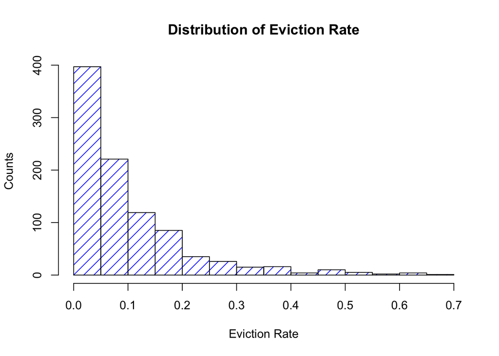

```r
eviction_2019_3 <- eviction_2019[-c(3)]
eviction_2019_3$Year <- "0"
eviction_2020$Year <- "1"
eviction_total <- rbind(eviction_2019_3, eviction_2020)
plot(hist(eviction_total$EvictionRate, plot = FALSE), col="blue",density=10,angle=45,xlab="Eviction Rate",ylab="Counts",main="Distribution of Eviction Rate")
```

The histogram plot shows the overall distribution of our dependent variables. In this plot, x axis is a number line that has been split into number ranges.the y-axis represents the number count of occurrences in the data for each column and are used to visualize data distributions. From the graph we could see the majority of our observations are between 0 to 0.2, meaning the distribution of eviction rate is skewed to right, This skewness means when we’re trying to run the mlr later in our regression part, we need to take log to our dependent variable to bring the skewed dependent variable to be more normal.

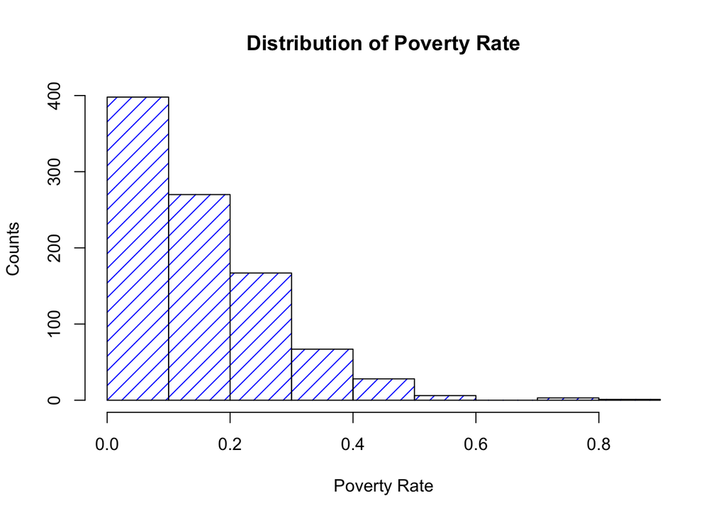

```r
plot(hist(eviction_total$PovertyRate, plot = FALSE), col="blue",density=10,angle=45,xlab="Poverty Rate",ylab="Counts",main="Distribution of Poverty Rate")
```

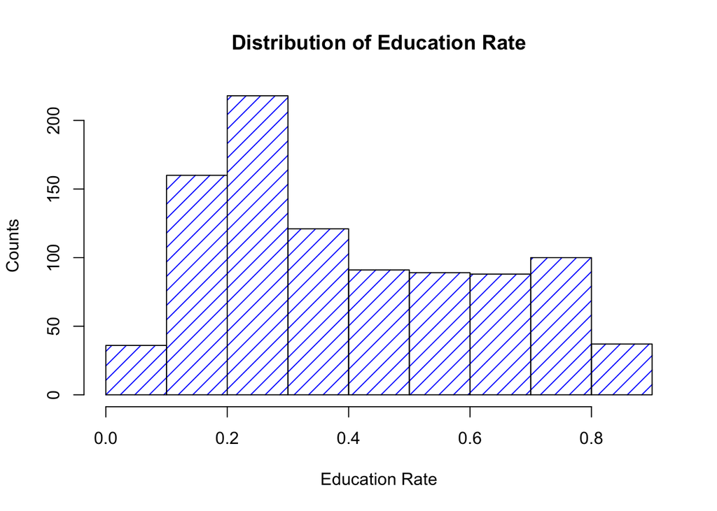

```r
plot(hist(eviction_total$EducationRate, plot = FALSE), col="blue",density=10,angle=45,xlab="Education Rate",ylab="Counts",main="Distribution of Education Rate")
```

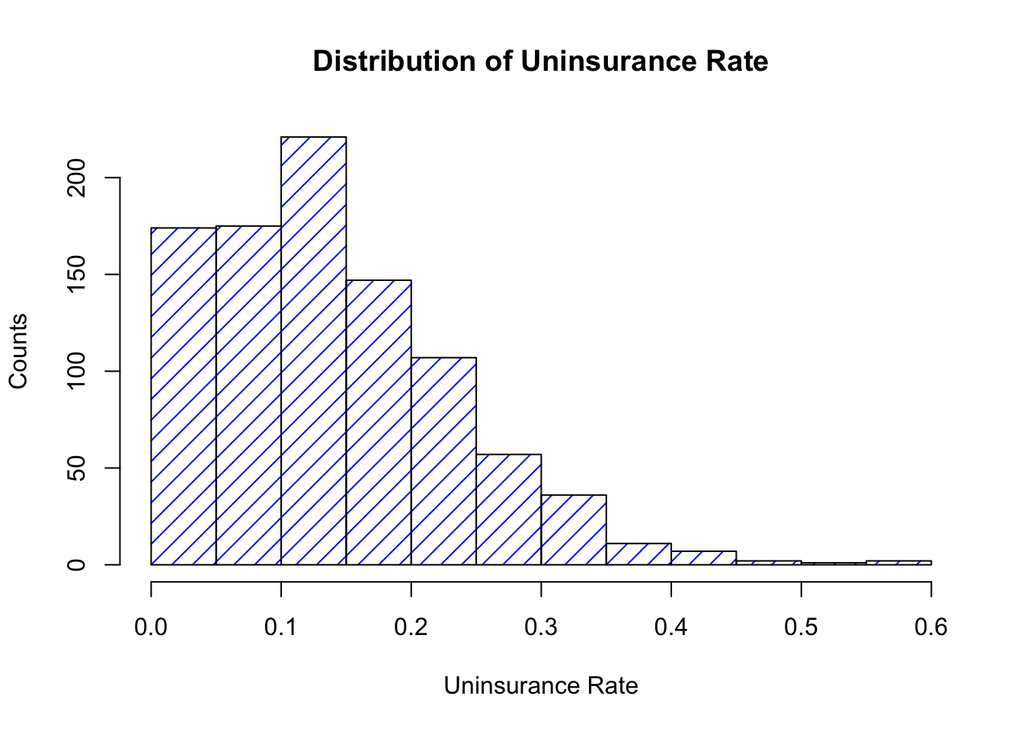

```r
plot(hist(eviction_total$UninsurRate, plot = FALSE), col="blue",density=10,angle=45,xlab="Uninsurance Rate",ylab="Counts",main="Distribution of Uninsurance Rate")
```

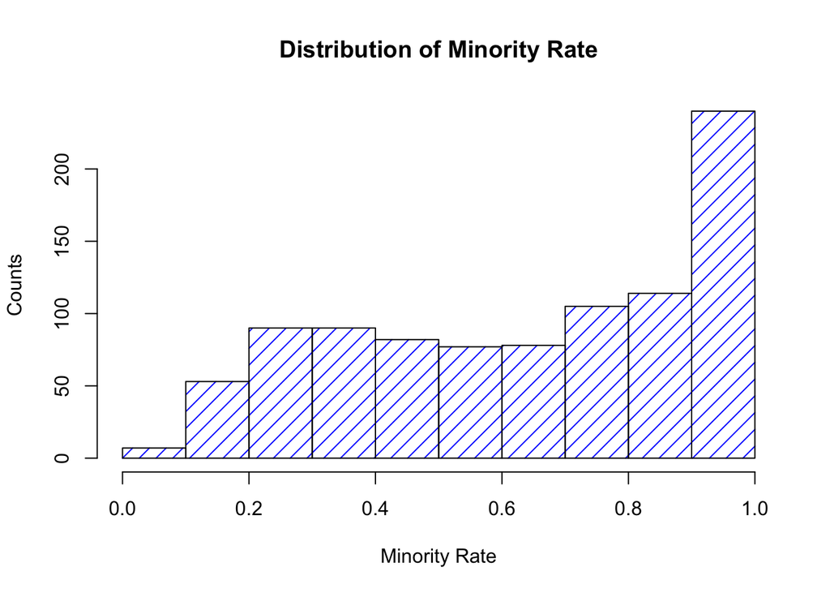

```r
plot(hist(eviction_total$MinorityRate, plot = FALSE), col="blue",density=10,angle=45,xlab="Minority Rate",ylab="Counts",main="Distribution of Minority Rate")
```

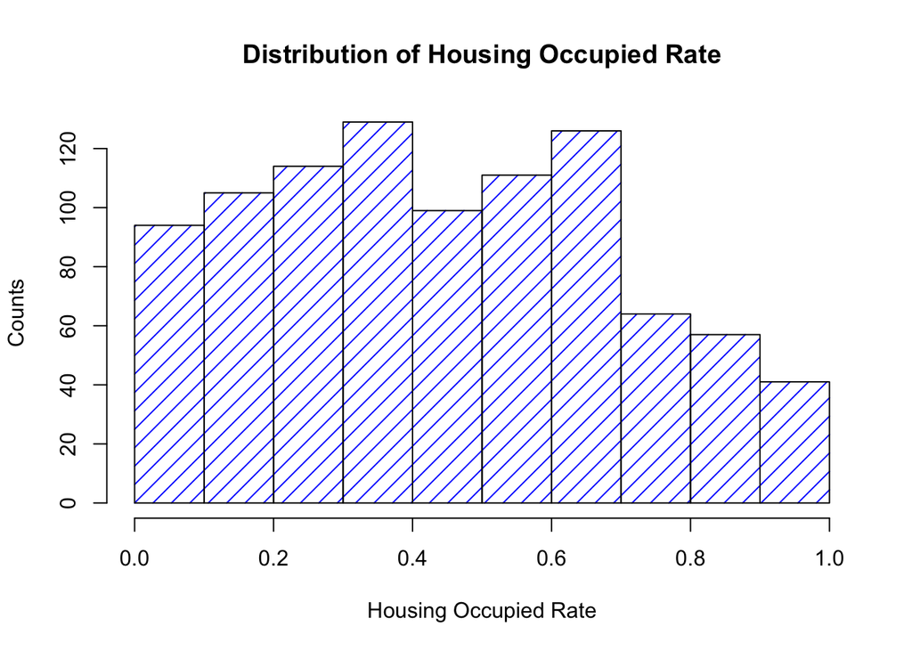

```r
plot(hist(eviction_total$RenterRate, plot = FALSE), col="blue",density=10,angle=45,xlab="Housing Occupied Rate",ylab="Counts",main="Distribution of Housing Occupied Rate")
```

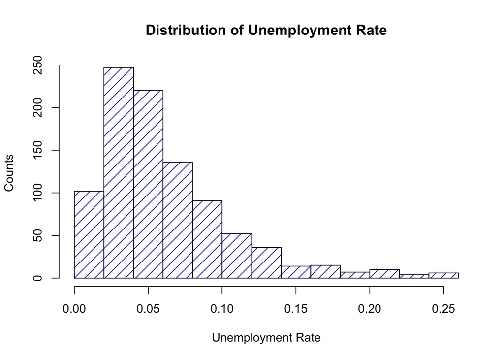

```r
plot(hist(eviction_total$UnempRate, plot = FALSE), col="blue",density=10,angle=45,xlab="Unemployment Rate",ylab="Counts",main="Distribution of Unemployment Rate")
```

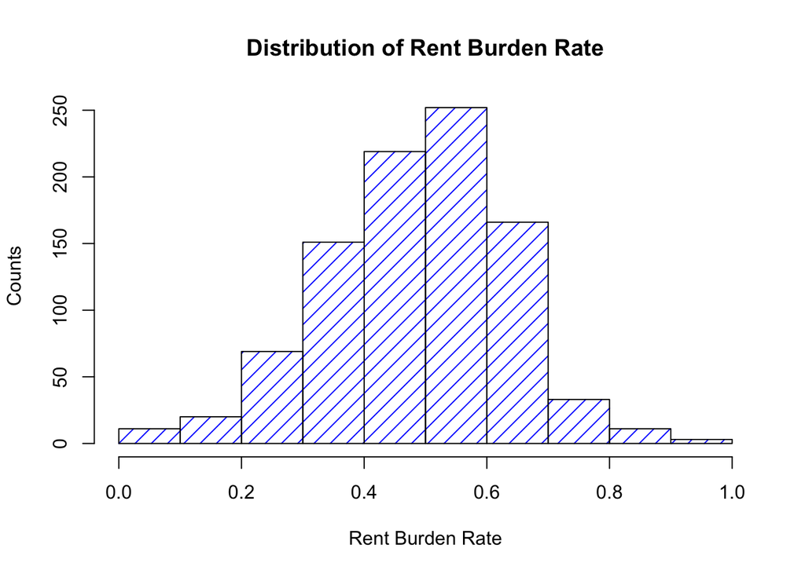

```r
plot(hist(eviction_total$RentBurdenRate, plot = FALSE), col="blue",density=10,angle=45,xlab="Rent Burden Rate",ylab="Counts",main="Distribution of Rent Burden Rate")
```

### 2. Multiple Linear Regression

Since we’ve discussed that the distribution of eviction rate is skewed to right and we need to take log to our dependent variable to bring the skewed dependent variable to be more normal. We could generate basic multiple linear regression equation:

Model 1
$$log(Eviction Rate) = \beta_0 + \beta_1*Poverty + \beta_2*Edutacion + \beta_3*RentBurden + \beta_4*Uninsurance + \beta_5*Minority + \beta_6*Renter + \beta_7*Unemployment + u$$

```r
fit1 <- lm(log(EvictionRate) ~ PovertyRate + EducationRate + RentBurdenRate + UninsurRate + MinorityRate + RenterRate + UnempRate, eviction_total)
stargazer(fit1,type = "html", covariate.labels = c("Poverty", "Education", "Rent Burden", "Uninsurance", "Minority", "Housing Occupied", "Unemployment"), dep.var.labels  = 'log(Eviction rate)', out.header=TRUE )
```

|  | *Dependent variable:* |
| --- | --- |
|  | log(Eviction rate) |
| Poverty | -2.506*** |
|  | (0.390) |
| Education | -1.077*** |
|  | (0.265) |
| Rent Burden | 0.291 |
|  | (0.206) |
| Uninsurance | -0.169 |
|  | (0.418) |
| Minority | 2.019*** |
|  | (0.199) |
| Housing Occupied | 3.261*** |
|  | (0.153) |
| Unemployment | -1.126 |
|  | (0.787) |
| Constant | -5.024*** |
|  | (0.249) |
| Observations | 931 |
| R<sup>2</sup> | 0.688 |
| Adjusted R<sup>2</sup> | 0.686 |
| Residual Std. Error | 0.794 (df = 923) |
| F Statistic | 291.062*** (df = 7; 923) |
| *Note:* | p<0.1; p<0.05; p<0.01 |

```r
kable(vif(fit1))
```

|  | x |
| --- | --- |
| PovertyRate | 3.027796 |
| EducationRate | 5.033308 |
| RentBurdenRate | 1.378443 |
| UninsurRate | 2.200675 |
| MinorityRate | 4.414054 |
| RenterRate | 2.220299 |
| UnempRate | 1.781776 |

From the chart we could see the results of our linear regression model, we first look at the R sqr at the bottom of the chart, in multiple linear regression, the R2 represents the correlation coefficient between the observed values of the outcome variable (y) and the fitted (i.e., predicted) values of y. Since the R^2 will increase as more x is included in the model, we introduce “Adjusted R Square”, which is the adjustment value in the summary output is a correction for the number of x variables included in the prediction model. In our model, the adjusted R^2 is around 69, which means the model explains 69% of the variance in the outcome variable, eviction rate. We then look back at the numbers on the top, those numbers outside the parentheses indicate the estimate of regression beta coefficients in our model, the star sign on the right of the number indicates the significance level, and the 3 stars indicates a factor to be the most significant. The number below inside the parentheses indicates the standard error of regression, representing the average distance that the observed values fall from the regression line. Looking back at regression beta coefficients, a positive coefficient means that this predictor variable will positively affect the eviction rate, while a negative coefficient means that this predictor variable will negatively affect the eviction rate, in other words, when it increases, the eviction rate will drop. From the chart, we could see poverty rate, education rate, uninsurance rate, and unemployment rate are negatively correlated, while housing occupied, minority rate and rent burden rate are positively correlated, we could also generate our models to be:

Model
$$log(Eviction rate) = -2.5060*Poverty - 1.0766*Edutacion + 0.2907*RentBurden + -0.1695*Uninsurance + 2.0186*Minority + 3.2613*Renter - 1.1260*Unemployment - 5.0242$$

From the equation and the significance level in the chart, we could see poverty, education, minority and housing occupied are the most significant factors.

### 3. Finding Outliers

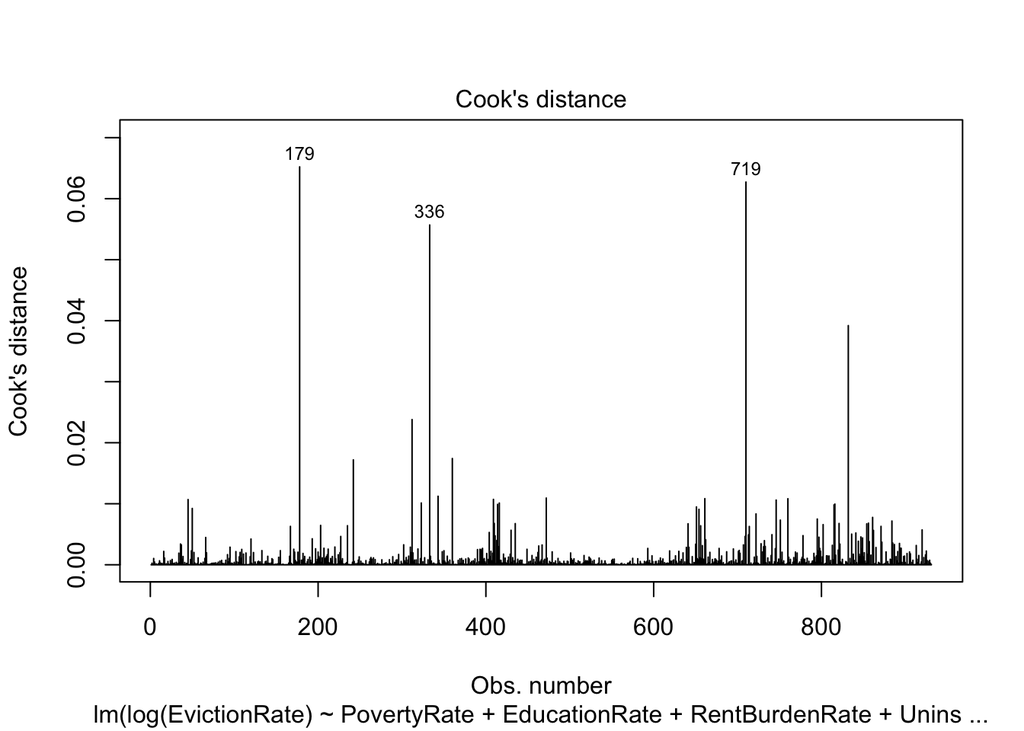

```r
plot(fit1, which = c(4))
```

```r
eviction_total_2 <- eviction_total[-c(179, 336, 719),]
fit2 <- lm(log(EvictionRate) ~ PovertyRate + EducationRate + RentBurdenRate + UninsurRate + MinorityRate + RenterRate + UnempRate, eviction_total_2)
stargazer(fit1, fit2,type = "html", covariate.labels = c("Poverty", "Education", "Rent Burden", "Uninsurance", "Minority", "Housing Occupied", "Unemployment"), dep.var.labels  = 'log(Eviction rate)', out.header=TRUE )
```

|  | *Dependent variable:* |  |
| --- | --- | --- |
|  | log(Eviction rate) |  |
|  | (1) | (2) |
| Poverty | -2.506*** | -2.462*** |
|  | (0.390) | (0.386) |
| Education | -1.077*** | -1.055*** |
|  | (0.265) | (0.261) |
| Rent Burden | 0.291 | 0.344* |
|  | (0.206) | (0.203) |
| Uninsurance | -0.169 | 0.142 |
|  | (0.418) | (0.424) |
| Minority | 2.019*** | 2.020*** |
|  | (0.199) | (0.196) |
| Housing Occupied | 3.261*** | 3.258*** |
|  | (0.153) | (0.151) |
| Unemployment | -1.126 | -1.684** |
|  | (0.787) | (0.780) |
| Constant | -5.024*** | -5.070*** |
|  | (0.249) | (0.245) |
| Observations | 931 | 928 |
| R<sup>2</sup> | 0.688 | 0.700 |
| Adjusted R<sup>2</sup> | 0.686 | 0.697 |
| Residual Std. Error | 0.794 (df = 923) | 0.780 (df = 920) |
| F Statistic | 291.062*** (df = 7; 923) | 306.018*** (df = 7; 920) |
| *Note:* | p<0.1; p<0.05; p<0.01 |  |

## 3. Analyzing the 2019 and 2020 data seperately to see COVID impact

Since we considered year 2019 as before COVID, and 2020 after COVID. We want to see how COVID-19 impacts the eviction rate, how the weights of our top factors vary. In order to do so, we separate our dataset into year 2019, and 2020, run the mlr again to see the difference.

### 1. Distribution Histogram

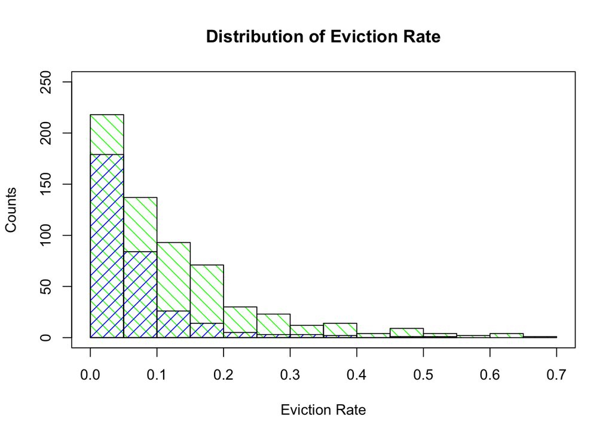

```r
evic_2019 <- hist(eviction_2019$EvictionRate, plot = FALSE)
evic_2020 <- hist(eviction_2020$EvictionRate, plot = FALSE)
plot(0,0,type="n",xlim=c(0,0.7),ylim=c(0,250),xlab="Eviction Rate",ylab="Counts",main="Distribution of Eviction Rate")
plot(evic_2019,col="green",density=10,angle=135,add=TRUE)
plot(evic_2020,col="blue",density=10,angle=45,add=TRUE)
```

We made a distribution plot to see the skewness of eviction rate for year 2019 and 2020 differently, in this graph, the green region indicates 2019 eviction rate, and blue indicates 2020. Since we have more observations in 2019 than 2020, we could see the columns for 2019 are higher, however, the distribution are similar, we could see for both 2019 and 2020, majority of our observations are between 0 to 0.2, meaning the distribution of eviction rate is skewed to right, This skewness means when we’re trying to run the mlr later in our regression part, we need to take log to our dependent variable to bring the skewed dependent variable to be more normal.

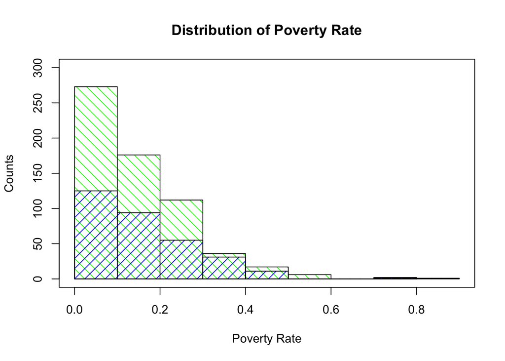

```r
pov_2019 <- hist(eviction_2019$PovertyRate, plot = FALSE)
pov_2020 <- hist(eviction_2020$PovertyRate, plot = FALSE)
plot(0,0,type="n",xlim=c(0,0.9),ylim=c(0,300),xlab="Poverty Rate",ylab="Counts",main="Distribution of Poverty Rate")
plot(pov_2019,col="green",density=10,angle=135,add=TRUE)
plot(pov_2020,col="blue",density=10,angle=45,add=TRUE)
```

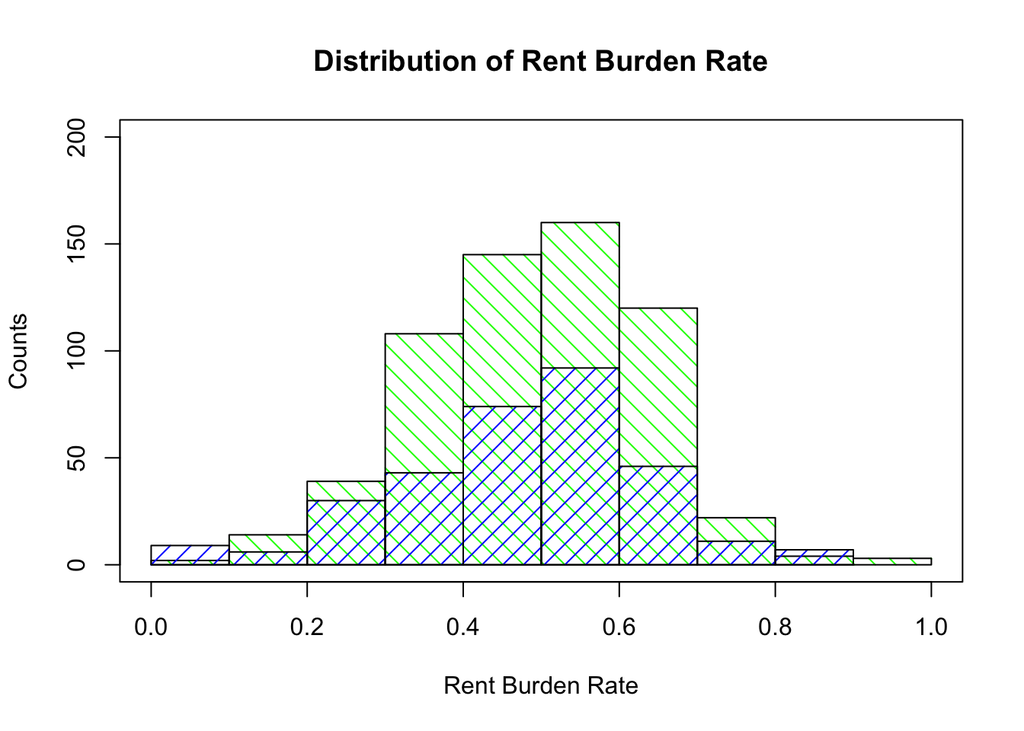

```r
rb_2019 <- hist(eviction_2019$RentBurdenRate, plot = FALSE)
rb_2020 <- hist(eviction_2020$RentBurdenRate, plot = FALSE)
plot(0,0,type="n",xlim=c(0,1),ylim=c(0,200),xlab="Rent Burden Rate",ylab="Counts",main="Distribution of Rent Burden Rate")
plot(rb_2019,col="green",density=10,angle=135,add=TRUE)
plot(rb_2020,col="blue",density=10,angle=45,add=TRUE)
```

We also take poverty rate and rent burden rate as an example to see the distribution of our independent variables, we could see the distribution of 2019 and 2020 for these two variables are also similar, while poverty rate is skewed to right, and rent burden rate is normally distributted

### 2. Bootstrapping to examine change in weekly evictions during pandemic

```r
# Preprocess data for the analyses
# import eviction filing data

# Define a function that restructures data for the hypothesis testing
compute_weekly_evictions <- function(df){
  # Remove observations that are missing census tract ID
  df <- df[df$TractID != 99999999999, ]

  # Split filing date into days, month, and years
  df <- separate(data = df, col = FilingDate, sep = "/",
                 into = c("Month", "Dates","Year"))

  df$Month=as.numeric(df$Month)
  df$Dates=as.numeric(df$Dates)
  df$Year=as.numeric(df$Year)

  df$Week <- ifelse(df$Dates>21, 4, ifelse(df$Dates>14, 3, ifelse(df$Dates>7,2, 1)))

  df <- df[df$Month>=4 & (df$Year==20 |df$Year==19),]
  df$Week=as.numeric(df$Week)
  df <- df %>% dplyr::group_by(TractID, Year, Month, Week) %>% dplyr::summarize("WeeklyFilings" = sum(TotalFilings))

  df19 <- as.data.frame(df[df$Year ==19,])
  df20 <- as.data.frame(df[df$Year ==20,])
  df <- df19 %>% dplyr::inner_join(df20, by = c("TractID"="TractID"))  %>%
    mutate("WeeklyFilings19" = WeeklyFilings.x,
           "WeeklyFilings20" = WeeklyFilings.y,
           "Month" = Month.x,
           "Year" = Year.x,
           "Week" = Week.x,
    "ChangeInWeeklyFilings" = WeeklyFilings20 - WeeklyFilings19,) %>%
    dplyr::select(TractID, Month, Week, WeeklyFilings20, WeeklyFilings19, ChangeInWeeklyFilings)
  return(df)
}
week_df <- compute_weekly_evictions(evictions)
```

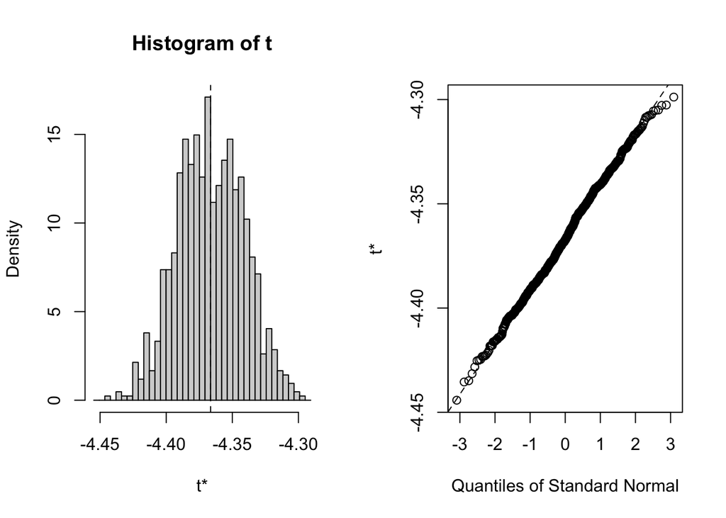

```r
cpr_19_20 <- function(df,indicies){
  d <- df[indicies,]
  return(mean(d$ChangeInWeeklyFilings))
}
r=boot(week_df, cpr_19_20, R=1000)
plot(r)
```

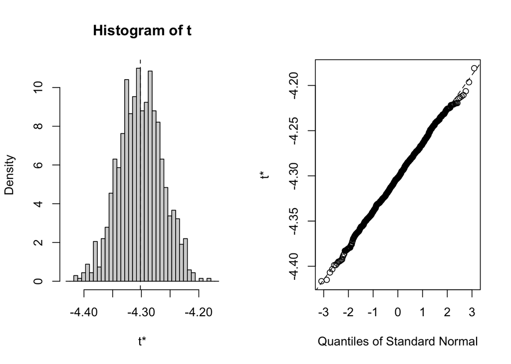

```r
rcc=boot(week_df[as.numeric(week_df$Month) < 8,],cpr_19_20, R=1000)
plot(rcc)
```

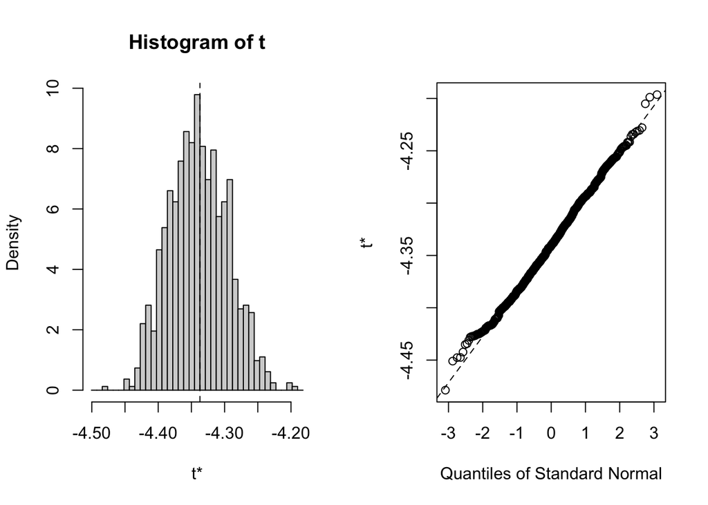

```r
rncc=boot(week_df[as.numeric(week_df$Month) > 9,],cpr_19_20, R=1000)
plot(rncc)
```

Distribution of sample means suggest that the weekly eviction filings reported was lower in 2020 than 2019 (CI: 95%).

### 3. Multiple linear regression

We took log to our dependent variable to bring the skewed dependent variable to be more normal. We could generate two basic multiple linear regression equations:

Model 1
$$log(Eviction 2019) = \beta_0 + \beta_1*Poverty + \beta_2*Edutacion + \beta_3*RentBurden + \beta_4*Uninsurance + \beta_5*Minority + \beta_6*Renter + \beta_7*Unemployment + u$$
Model 2
$$log(Eviction 2020) = \beta_0 + \beta_1*Poverty + \beta_2*Edutacion + \beta_3*RentBurden + \beta_4*Uninsurance + \beta_5*Minority + \beta_6*Renter + \beta_7*Unemployment + u$$

```r
fit3 <- lm(log(EvictionRate) ~ PovertyRate + EducationRate + RentBurdenRate + UninsurRate + MinorityRate + RenterRate + UnempRate, eviction_2019)
fit4 <- lm(log(EvictionRate) ~ PovertyRate + EducationRate + RentBurdenRate + UninsurRate + MinorityRate + RenterRate + UnempRate, eviction_2020)
stargazer(fit3, fit4,type = "html", covariate.labels = c("Poverty", "Education", "Rent Burden", "Uninsurance", "Minority", "Housing Occupied", "Unemployment"), dep.var.labels  = 'log(Eviction rate)', out.header=TRUE )
```

|  | *Dependent variable:* |  |
| --- | --- | --- |
|  | log(Eviction rate) |  |
|  | (1) | (2) |
| Poverty | -2.510*** | -2.356*** |
|  | (0.456) | (0.554) |
| Education | -1.224*** | -0.219 |
|  | (0.290) | (0.418) |
| Rent Burden | -0.201 | 0.429 |
|  | (0.230) | (0.311) |
| Uninsurance | -0.587 | 0.847 |
|  | (0.448) | (0.676) |
| Minority | 1.936*** | 2.545*** |
|  | (0.207) | (0.345) |
| Housing Occupied | 3.378*** | 3.065*** |
|  | (0.170) | (0.237) |
| Unemployment | 0.555 | -0.822 |
|  | (0.994) | (1.028) |
| Constant | -4.506*** | -6.368*** |
|  | (0.269) | (0.400) |
| Observations | 613 | 318 |
| R<sup>2</sup> | 0.740 | 0.740 |
| Adjusted R<sup>2</sup> | 0.737 | 0.734 |
| Residual Std. Error | 0.686 (df = 605) | 0.747 (df = 310) |
| F Statistic | 246.250*** (df = 7; 605) | 126.072*** (df = 7; 310) |
| *Note:* | p<0.1; p<0.05; p<0.01 |  |

From the equation and the significance level in the chart, we could see education is significant in year 2019 but not in 2020.